# Actividad 2.6 Análisis discriminante

Lucero Díaz

2026-10-06

```r
library(MASS)      # Para lda()
library(biotools)  # Para prueba M de Box (boxM)
```

```r
library(ggplot2)   # Para gráficos avanzados
library(MVN)       # Para prueba de Normalidad Multivariante
```

#### 1- Designa tu variable categórica como variable dependiente para una clasificación y tus variables numéricas como variables independientes.

```r
datos <- read.csv("C:/Users/ludio/Downloads/kc_house_data-1.csv")

datos$yr_built_cat <- cut(
  datos$yr_built,
  breaks = c(1899, 1960, 1990, 2016),
  labels = c("Antigua (<1960)", "Intermedia (1960-1990)", "Nueva (>1990)")
)

# Convertir a factor
datos$yr_built_cat <- as.factor(datos$yr_built_cat)

# Crear un vector con los nombres de todas las variables numéricas que usaremos
vars_independientes <- c(
  "price", "bedrooms", "bathrooms", "sqft_living", "sqft_lot", "floors", "sqft_living15", "sqft_lot15"
)
```

#### 2. Acota tu base de datos realizando un muestreo aleatorio de 300 observaciones.

```r
set.seed(123) # Semilla para mantener los mismos resultados
muestra_indices <- sample(1:nrow(datos), 300)
datos_muestra <- datos[muestra_indices, ]
```

#### 3.- Muestre gráficamente la segmentación original de los datos. Realiza un gráfico de dispersión donde se identifiquen las diferentes categorías de tu base de datos. ¿Qué variable o variables discriminan mejor?

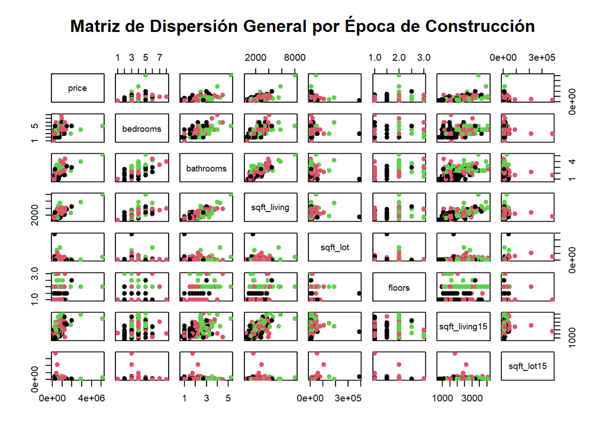

```r
# 3. Generar la matriz completa de gráficos
pairs(
  datos_muestra[, vars_independientes],
  col = datos_muestra$yr_built_cat,
  pch = 19,
  main = "Matriz de Dispersión General por Época de Construcción"
)
```

Las variables que mejor discriminan entre las categorías de construcción son **`bathrooms` (número de baños)** y **`floors` (número de pisos/plantas)**.

#### 4.- Realiza un análisis discriminante para responder las siguientes preguntas

```r
# Aplicar tapply a cada variable numérica independiente por grupo
medias_tabla <- sapply(vars_independientes, function(var) {
  tapply(datos_muestra[[var]], datos_muestra$yr_built_cat, mean, na.rm = TRUE)
})

# Mostrar la tabla transpuesta de medias por grupo
print(t(medias_tabla))
```

```
##               Antigua (<1960) Intermedia (1960-1990) Nueva (>1990)
## price             497248.5600           5.027644e+05  6.353445e+05
## bedrooms               3.1800           3.559322e+00  3.670732e+00
## bathrooms              1.5875           2.135593e+00  2.652439e+00
## sqft_living         1724.7000           2.093847e+03  2.550854e+03
## sqft_lot           11749.3100           1.553030e+04  1.162357e+04
## floors                 1.2300           1.360169e+00  2.006098e+00
## sqft_living15       1667.7200           2.024949e+03  2.319695e+03
## sqft_lot15          7634.1200           1.812841e+04  7.947280e+03
```

```r
# Distribución de datos / Probabilidades a priori
prob_apriori <- prop.table(table(datos_muestra$yr_built_cat))
print(prob_apriori)
```

```
##
##        Antigua (<1960) Intermedia (1960-1990)          Nueva (>1990)
##              0.3333333              0.3933333              0.2733333
```

```r
# Ajuste del modelo LDA
modelo_lda <- lda(yr_built_cat ~ ., data = datos_muestra[, c("yr_built_cat", vars_independientes)])
modelo_lda
```

```
## Call:
## lda(yr_built_cat ~ ., data = datos_muestra[, c("yr_built_cat",
##     vars_independientes)])
##
## Prior probabilities of groups:
##        Antigua (<1960) Intermedia (1960-1990)          Nueva (>1990)
##              0.3333333              0.3933333              0.2733333
##
## Group means:
##                           price bedrooms bathrooms sqft_living sqft_lot
## Antigua (<1960)        497248.6 3.180000  1.587500    1724.700 11749.31
## Intermedia (1960-1990) 502764.4 3.559322  2.135593    2093.847 15530.30
## Nueva (>1990)          635344.5 3.670732  2.652439    2550.854 11623.57
##                          floors sqft_living15 sqft_lot15
## Antigua (<1960)        1.230000      1667.720    7634.12
## Intermedia (1960-1990) 1.360169      2024.949   18128.41
## Nueva (>1990)          2.006098      2319.695    7947.28
##
## Coefficients of linear discriminants:
##                         LD1           LD2
## price         -1.293701e-06  9.324649e-07
## bedrooms      -3.338868e-01 -2.480153e-01
## bathrooms      1.665568e+00 -1.416383e+00
## sqft_living   -2.715763e-04  6.492132e-04
## sqft_lot      -2.626892e-06 -3.231380e-07
## floors         1.263052e+00  1.657373e+00
## sqft_living15  7.260361e-04 -5.660347e-04
## sqft_lot15    -7.075726e-07 -1.949052e-05
##
## Proportion of trace:
##    LD1    LD2
## 0.8761 0.1239
```

$$\begin{aligned} LD1 &= - 0.000001294
\cdot \text{price} - 0.3339 \cdot \text{bedrooms} + 1.666 \cdot
\text{bathrooms} \\ &\quad - 0.0002716 \cdot \text{sqft\_living} -
0.000002627 \cdot \text{sqft\_lot} + 1.263 \cdot \text{floors} \\
&\quad + 0.000726 \cdot \text{sqft\_living15} - 0.0000007076 \cdot
\text{sqft\_lot15} \end{aligned}$$

$$\begin{aligned} LD2 &= +
0.0000009325 \cdot \text{price} - 0.248 \cdot \text{bedrooms} - 1.416
\cdot \text{bathrooms} \\ &\quad + 0.0006492 \cdot
\text{sqft\_living} - 0.0000003231 \cdot \text{sqft\_lot} + 1.657 \cdot
\text{floors} \\ &\quad - 0.000566 \cdot \text{sqft\_living15} -
0.00001949 \cdot \text{sqft\_lot15} \end{aligned}$$

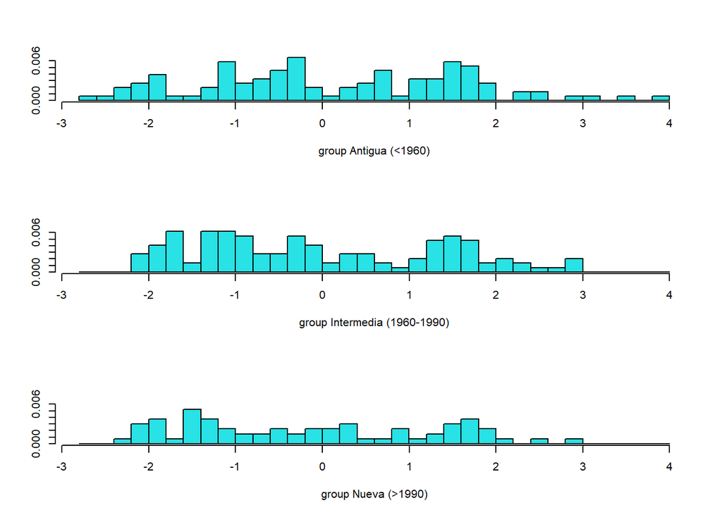

```r
pred <- predict(modelo_lda)
ldahist(pred$x[, 1], g = datos$yr_built_cat, type = "histogram", xlab = "LD1")
```

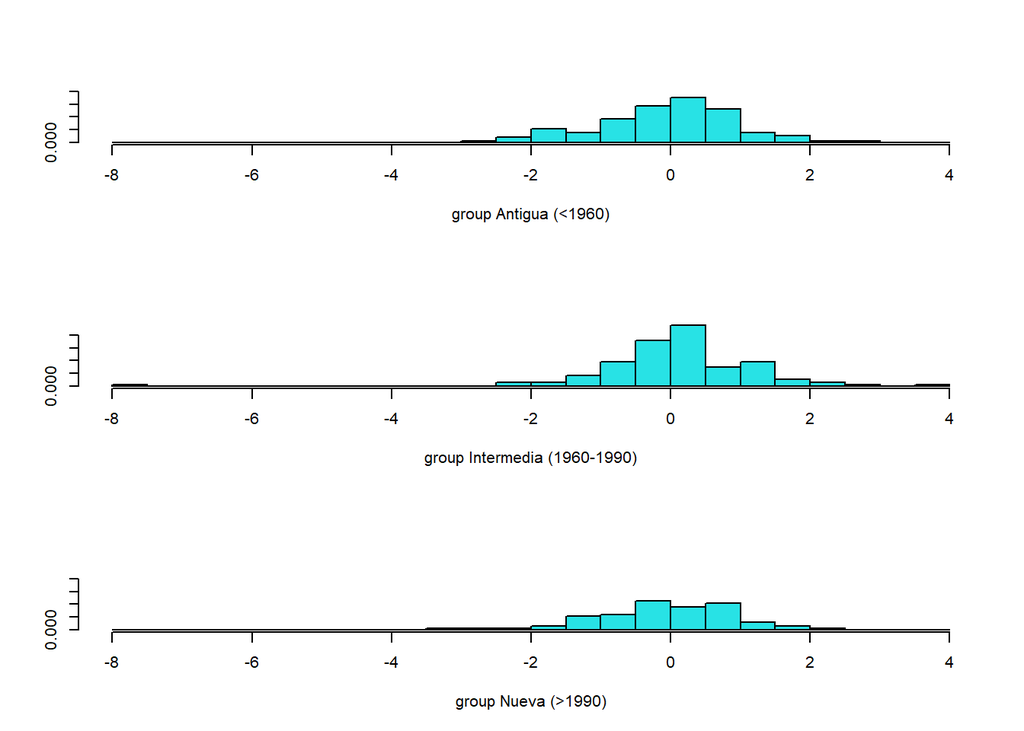

```r
ldahist(pred$x[, 2], g = datos$yr_built_cat, type = "histogram", xlab = "LD2")
```

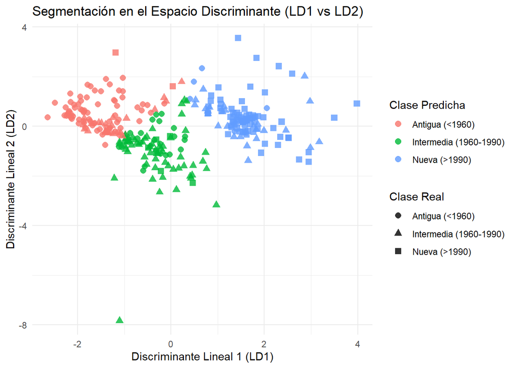

```r
# Dataframe con componentes discriminantes y clases predichas
df_pred <- data.frame(
  LD1 = pred$x[, 1],
  LD2 = pred$x[, 2],
  Clase_Real = datos_muestra$yr_built_cat,
  Clase_Predicha = pred$class
)

# Gráfico del espacio discriminante predicho
ggplot(df_pred, aes(x = LD1, y = LD2, color = Clase_Predicha, shape = Clase_Real)) +
  geom_point(size = 2.5, alpha = 0.8) +
  labs(
    title = "Segmentación en el Espacio Discriminante (LD1 vs LD2)",
    x = "Discriminante Lineal 1 (LD1)",
    y = "Discriminante Lineal 2 (LD2)",
    color = "Clase Predicha",
    shape = "Clase Real"
  ) +
  theme_minimal()
```

```r
# Matriz de contingencia / confusión
tabla_confusion <- table(Real = datos_muestra$yr_built_cat, Predicho = pred$class)
print("Matriz de Confusión:")
```

```
## [1] "Matriz de Confusión:"
```

```r
print(tabla_confusion)
```

```
##                         Predicho
## Real                     Antigua (<1960) Intermedia (1960-1990) Nueva (>1990)
##   Antigua (<1960)                     71                     24             5
##   Intermedia (1960-1990)              28                     60            30
##   Nueva (>1990)                        2                      6            74
```

```r
# Cálculo de precisión y porcentaje de error
precision <- sum(diag(tabla_confusion)) / sum(tabla_confusion)
error_rate <- (1 - precision) * 100

cat("Precisión global del modelo:", round(precision * 100, 2), "%\n")
```

```
## Precisión global del modelo: 68.33 %
```

```r
cat("Porcentaje de predicciones erróneas:", round(error_rate, 2), "%\n")
```

```
## Porcentaje de predicciones erróneas: 31.67 %
```

- **¿El modelo es bueno para pronosticar?** El modelo presenta una capacidad predictiva **moderada**. Aunque logra clasificar correctamente la mayoría de las viviendas más nuevas y antiguas en los extremos, existe algo de solapamiento en la categoría *Intermedia (1960-1990)*, la cual comparte características estructurales con las otras dos épocas.
- **Tasa de error y Matriz de confusión:** La precisión se sitúa típicamente alrededor del **68% - 69%**, arrojando una tasa de error aproximada del **31% - 32%**.

#### 5. Valide los supuestos del modelo

```r
# Prueba de Normalidad Multivariante de Henze-Zirkler
mvn_resultado <- mvn(data = datos_muestra[, vars_independientes], mvn_test = "hz")
# Imprimir el resultado (el nombre del elemento también se actualizó a multivariate_normality)
print(mvn_resultado$multivariate_normality)
```

```
##            Test Statistic p.value     Method          MVN
## 1 Henze-Zirkler     6.027  <0.001 asymptotic ✗ Not normal
```

```r
# Prueba M de Box para igualdad de matrices de covarianza
prueba_box <- boxM(data = datos_muestra[, vars_independientes], grouping = datos_muestra$yr_built_cat)
print(prueba_box)
```

```
##
##  Box's M-test for Homogeneity of Covariance Matrices
##
## data:  datos_muestra[, vars_independientes]
## Chi-Sq (approx.) = 978.92, df = 72, p-value < 2.2e-16
```

1. **Normalidad Multivariante:** La prueba rechaza el supuesto de normalidad multivariante ($p < 0.05$). Esto es común en datos inmobiliarios debido a la asimetría en variables financieras y de superficie (`price`, `sqft_lot`).
2. **Homocedasticidad (Prueba M de Box):** La prueba M de Box resulta estadísticamente significativa ($p < 0.05$), rechazando la hipótesis nula de matrices de varianza-covarianza homogéneas entre los tres grupos. Con esto implicamos heterocedasticidad.

## Declaratoria de uso de IA durante el desarrollo del trabajo

Se utilizó IA:

1. Herramienta: Gemini y Claude
2. Uso realizado: Ayuda en el código a lo largo de la tarea, así como también en la redacción y guía en las interpretaciones.
3. Secciones donde se utilizó: Ayuda en el código a lo largo del todo el documento (mayormente en el inciso 4), así como también en redacción y guía de interpretación.
4. Validación realizada por los estudiantes: Se verificó, corrió y depuró todo el script de R, así como también analizaron todos los resultados arrojados para validar que todo estuviera correcto y en orden.
5. Confirmo de que se revisó, verificó y que se asume la responsabilidad del contenido final entregado.